# Results — 05/15/26

## Exclusions

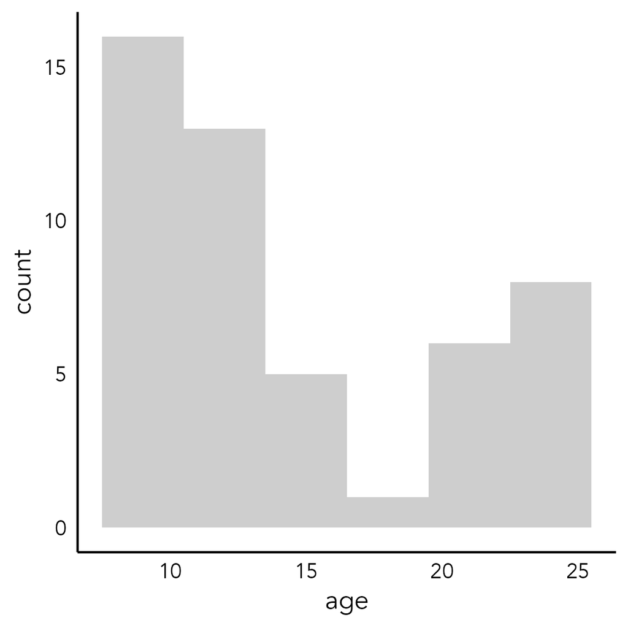

## Learning Phase results

### Participants learn well, regardless of age

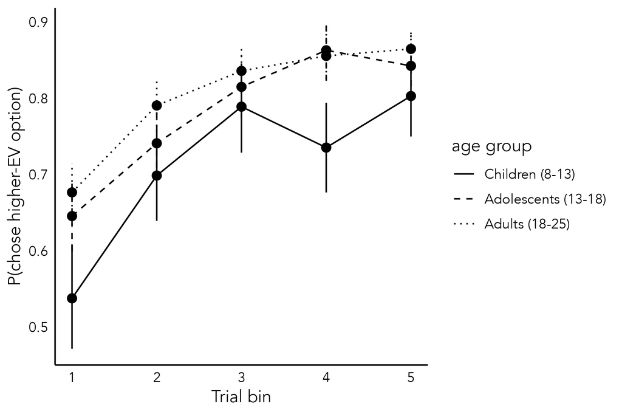

- Only includes trials in which one machine’s expected value is greater than the other. Error bars are 95% CI.
- After exclusions, performance across age groups was very similar.

### Participants show a negativity bias overall

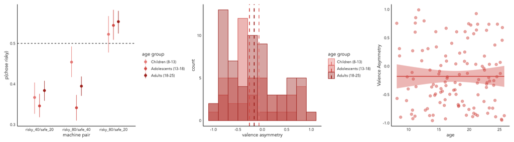

```r
knitr::include_graphics("learning_plots/age_valence_asymm.png")
```

- Unlike Gail and Noam, we do not see a stronger negativity bias in older participants.
- No age-related differences in model-derived valence asymmetry in learning rate.

## Memory Phase results

### Memory performance isn’t great

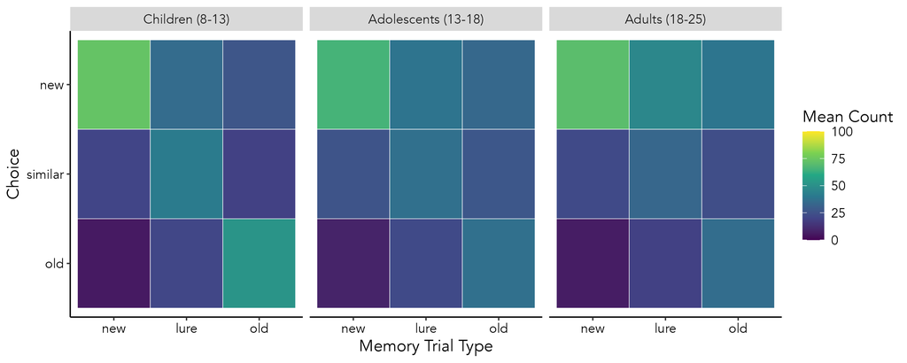

```r
knitr::include_graphics("memory_plots/age_groups_average_heatmap_facet.png")
```

- Performance isn’t amazing.
- Children seem to be doing better than adults.